# 白葡萄酒质量分析-Ivan

# 多变量绘图选择

查看不同评分下so2_ppm的分布密度图：

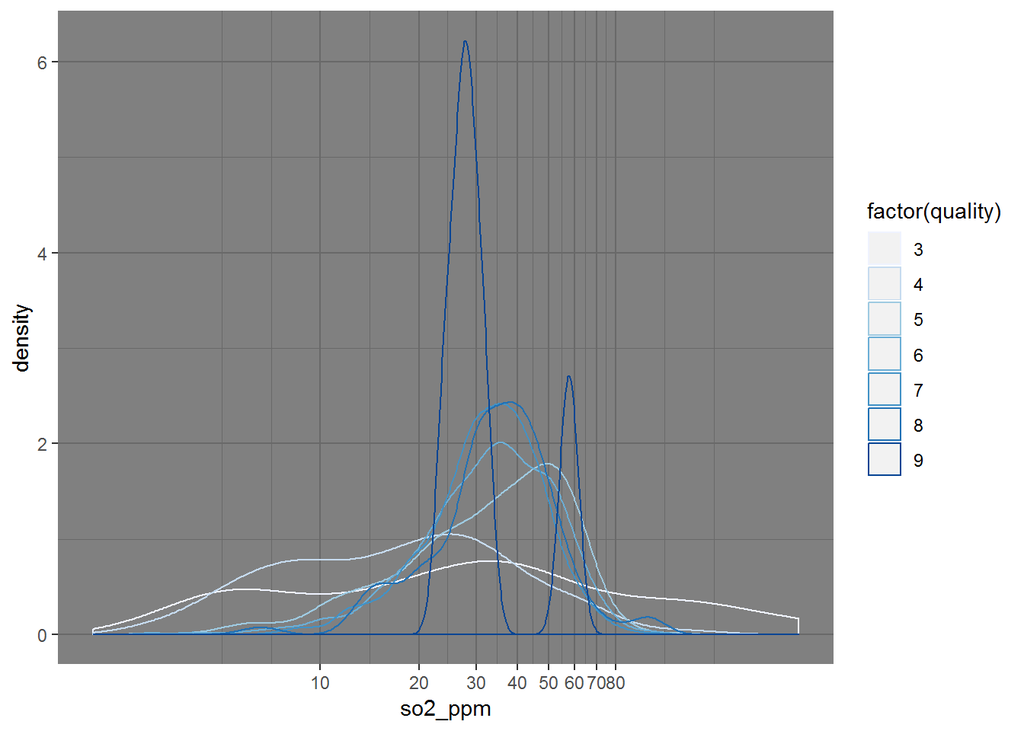

着重观察20到70之间的值分布情况：

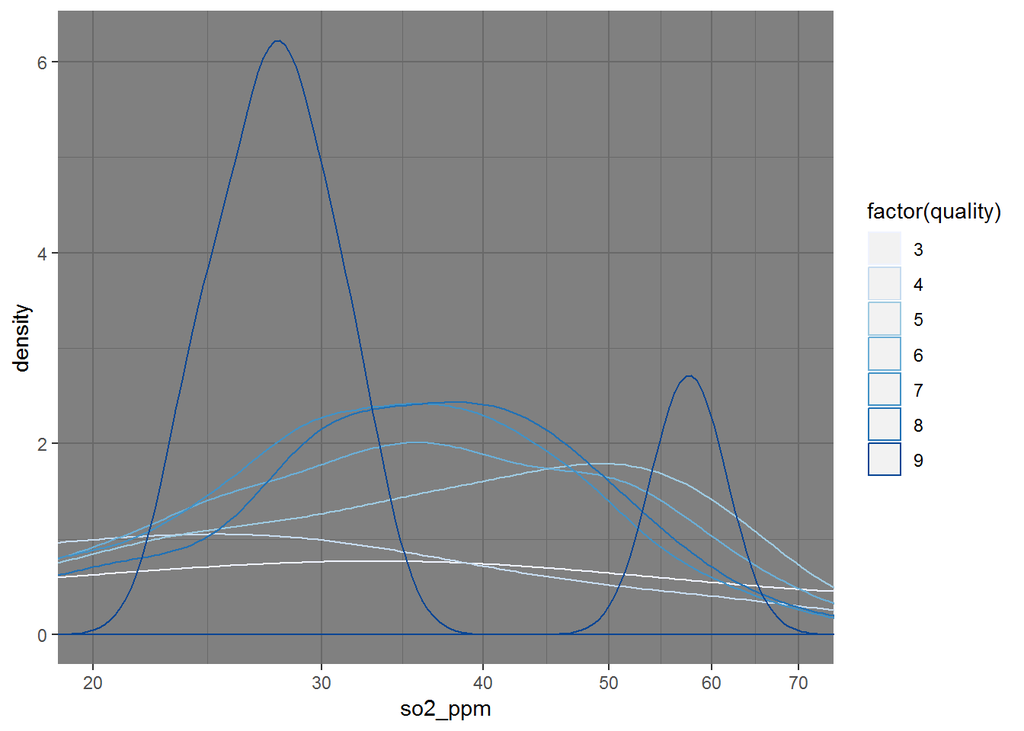

评分最高的酒so2_ppm值在26和56左右出现最多。

查看不同评分下密度的分布密度图：

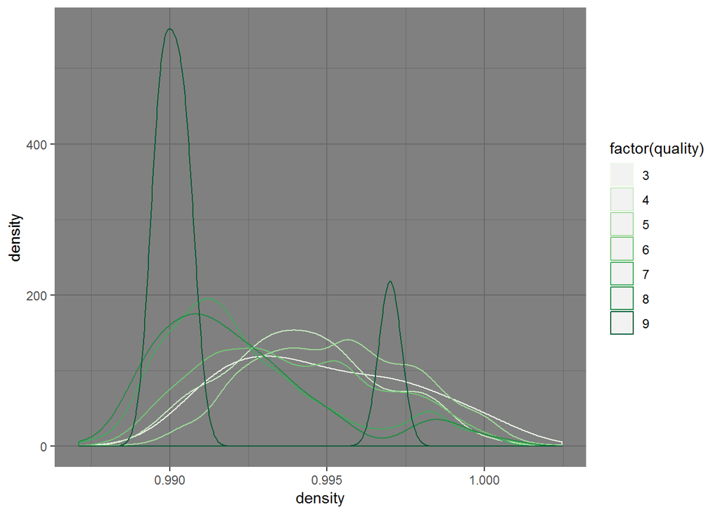

在评分最高的酒当中，密度出现最多的值在0.990和0.997左右。

查看不同评分下，密度和酒精度关系：

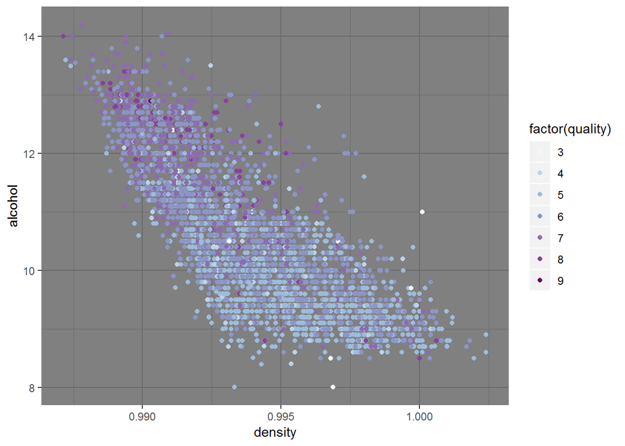

总体来看，低密度高酒精度的酒评分更高一些。

查看不同评分下，密度和残糖关系：

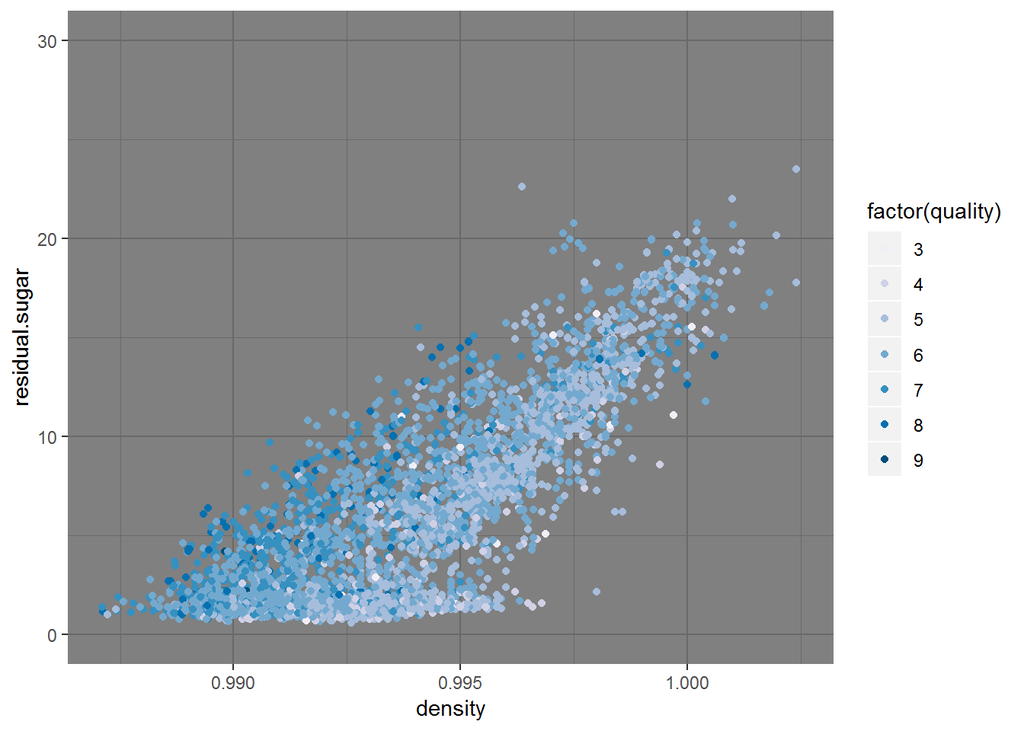

在同样的残糖条件下，一般密度低的酒获得的评分较高。

# 多变量分析

### 探讨你在这部分探究中观察到的一些关系。通过观察感兴趣的特性，是否存在相互促进的特性？

评分最高的酒so2_ppm值在26和56左右出现最多;总体来看，低密度高酒精度的酒评分更高一些;在同样的残糖条件下，一般密度低的酒获得的评分较高。

### 选项：你是否创建过数据集的任何模型？讨论你模型的优缺点。

# 定稿图与总结

### 绘图一

酒的不同评分的分布情况：

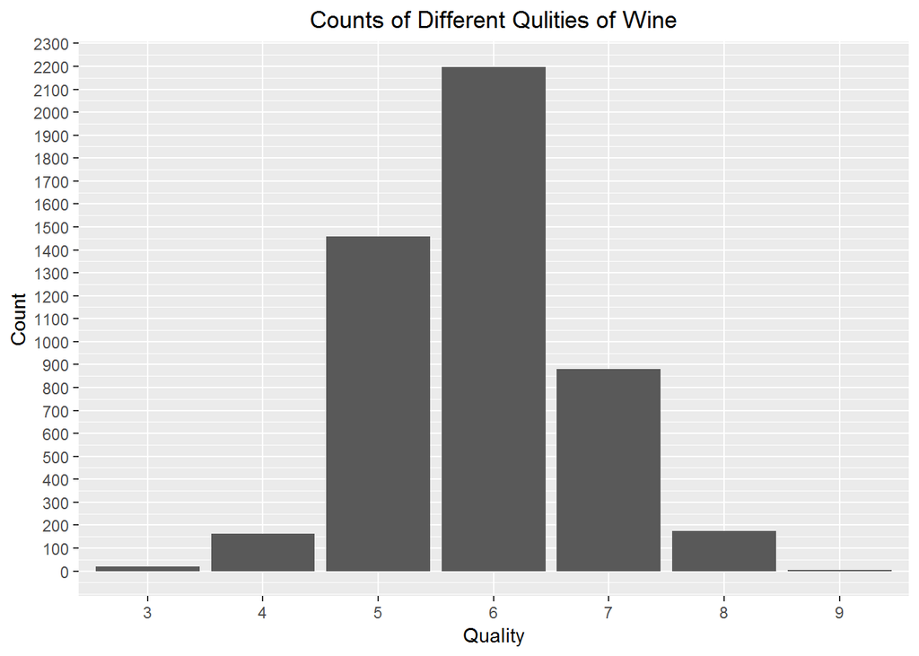

### 描述一

评分情况基本呈现正态分布，6分最多，3分，9分最少，没有出现1分或10分的情况。

### 绘图二

密度和评分的关系：

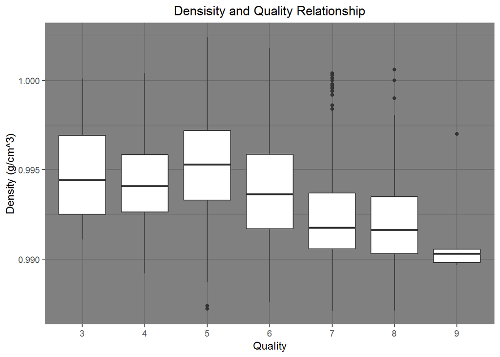

### 描述二

作为与评分相关性最强的变量，在不同的评分中，密度呈现一定的线型趋势，评分越高，密度的中位数下降（除了评分5比评分4的密度中位数要高）。

### 绘图三

不同评分下，密度和酒精度关系：

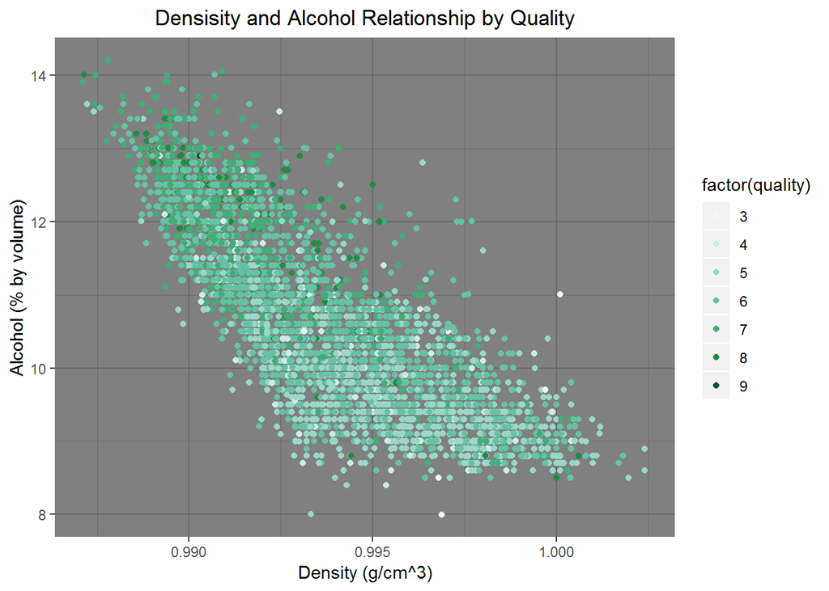

### 描述三

酒精度和密度呈现较强的负相关关系，并且和评分相关，在上图中可以比较明显地看出来。在评分较高的酒中，一般密度低、酒精度高，在评分较低的酒中，一般密度高，酒精度低。  
在同样密度的酒之间，酒精度高的一般评分高；在同样酒精度的酒之间，不同密度的酒的评分对比不明显。

# 反思

在这个数据集中，分析了近5000中白葡萄酒的评分和参数的关系。总体来看，评分没有和任何一个特定的参数呈现强相关关系，说明酒的品质不能单独取决于一两个参数。在此前提下，密度和酒精度是两个相关性相对较强的指标。密度和评分负相关，酒精度和评分正相关。同时。密度和残糖、二氧化硫相关变量正相关。这与直觉基本一致，人们似乎更喜欢口感‘清冽’和‘醉人’的白葡萄酒。关于预测评分模型的建立，有待进一步研究。

在分析时，由于评分没有和任何一个变量具有强相关关系，导致如果需要建模，对选取哪个变量比较困难，但是通过对比可以发现，变量中，密度、残糖和二氧化硫相关变量都是正相关的，密度和酒精度负相关，这为选择变量提供了思路。

在进一步分析时。应该可以考虑将某些连续变量通过分组转变为分类变量，以进一步观察不同从变量之间的关系。不过，鉴于决定评分的参数较多，在条件允许的情况下，建议还是选择尽可能多的变量参与建模，提高准确度。